# Tutorial Outline

1. Data accessibility
2. Set up environment
3. Quality control on raw reads
4. ABySS: de novo sequence assembler
5. SPAdes: de Bruijn graph based assembler
6. QUAST: assembly statistics
7. SSPACE Standard
8. AlignGraph on close relation

# 1. Data accessibility

This tutorial will serve as an example of how to use free and open-source genome assembly and secondary scaffolding tools to generate high quality assemblies of bacterial sequence data. The bacterial sample used in this tutorial will be referred to simply as “Species” but comes from the NCBI SRA run [SRR5714000](https://www.ncbi.nlm.nih.gov/sra/SRX2934374). This data is paired-end data, meaning that there are forward and reverse reads, which we will designate as SRR5714000_1.fastq and SRR5714000_2.fastq, respectively.

The data sets are available on the server:

```
Path: /home/WWU/BIOL497R/data/assembly
Data sets: SRR5714000_1.fastq.gz   SRR5714000_2.fastq.gz
```

# 2. Set up environment

In this exercise, we will be using multiple software programs, below is a list and links to more information.

- [Sickle](https://github.com/najoshi/sickle)
- [ABySS](https://github.com/bcgsc/abyss)
- [SPAdes](http://cab.spbu.ru/software/spades/)
- [QUAST](http://cab.spbu.ru/software/quast/)
- SSPACE
- AlignGraph

# 3. Quality control on raw reads

The first step is to perform quality control on the reads using sickle. To run the program we will use the sickle command. Since our reads are paired-end reads, we indicate this with the `pe` option. The `-f` flag designates the input file containing the forward reads, `-r` the input file containing the reverse reads, `-o` the output file containing the trimmed forward reads, `-p` the output file containing the trimmed reverse reads, and `-s` the output file containing trimmed singles. The `-q` flag designates the minimum quality, `-l` the minimum read length, and `-t` designates the type of read.

```python
%%bash

DATA="/home/WWU/BIOL497R/data/assembly"

sickle pe -f $DATA/SRR5714000_1.fastq.gz -r $DATA/SRR5714000_2.fastq.gz -t sanger \
          -o SRR5714000_sickle_1.fastq -p SRR5714000_sickle_2.fastq -s SRR5714000_sickle_s.fastq \
          -q 30 -l 45
```

The trimmed output from sickle will now be located in your folder `~/BIOL497R/notebooks/Ex5_assembly/`

# 4. ABySS: de novo sequence assembler

ABySS is the first assembly program we will use to assemble the trimmed reads. Since our reads are paired-end reads, to run the assembler we will use the `abyss-pe` command. We will use the parameters `k` for the size of the kmer, `name` for the output file prefix, `in` for the paths to the forward/reverse trimmed reads, and `se` for the path to the singles file, `np` for number of processors.

```python
%%bash

#ABySS must be run in its own cell
abyss-pe np=4 k=31 name=Species_Kmer31 in='SRR5714000_sickle_1.fastq SRR5714000_sickle_2.fastq' se='SRR5714000_sickle_s.fastq'
```

```python
%%bash

#move your results to a new folder
mkdir species-kmer31

mv Species_Kmer31* species-kmer31
```

The assembly output files should now be located in `~/BIOL497R/notebooks/Ex5_assembly/species-kmer31` and the results table in html format is easy to view `Species_Kmer31-stats.html`.

Unfortunately, many genome assembly protocols require a lot of manual optimization and this optimization involves generating assemblies at different k-mer length. **Repeat the analysis using k=35 and k=41**.

```python
%%bash
```

# 5. SPAdes: de Bruijn graph based assembler

The second assembler we will run is SPAdes. SPAdes is different from the ABySS assembler in that it generates a final assembly from multiple kmers. A list of kmers is automatically selected by SPAdes using the maximum read length of the input data, and each individual kmer contributes to the final assembly. To run SPAdes we will use the **`spades.py`** command with the `--careful` option to minimize the number of mismatches in the contigs, `-o` for the output folder, `-1` for the path to the forward reads, `-2` for the path to the reverse reads, and `-s` for the path to the singles reads. If desired, a list of kmers can be specified with the `-k` flag which will override automatic kmer selection and the number of threads can be specified with the `-t` option. Please done use more than 4 threads.

```python
%%bash

#view spades options
spades.py --help
```

```python
%%bash

spades.py --careful -o SPAdes_out -1 SRR5714000_sickle_1.fastq -2 SRR5714000_sickle_2.fastq -s SRR5714000_sickle_s.fastq
```

The SPAdes assembly output files will be located in `~/BIOL497R/notebooks/Ex5_assembly/SPAdes_out`

# 6. QUAST: assembly statistics

Now that we have several assemblies, it’s time to analyze the quality of each assembly. ABySS has their own statistics output, but for consistency, we will be using the program QUAST. The statistics we are most interested in are number of contigs, total length, and N50. A good assembly would have a low number of contigs, a total length that makes sense for the species, and a high N50 value. To run quast on all of our final assembly files we will run the following commands, with the only parameters used being the name of the assembly file(s) and output directory.

```python
%%bash

# ABySS statistics on all k-mers (kmer* where "*" is a wildcard)
quast.py species-kmer*/Species_Kmer*-scaffolds.fa -o ABySS

# SPAdes statistics
quast.py SPAdes_out/scaffolds.fasta -o SPAdes
```

QUAST’s output consists of a folder (ABySS or SPAdes) containing results in multiple formats. Your results should look similar to the numbers below.

### ABySS results:

| Assembly | # contigs | Largest contig | Total length | GC (%) | N50 |
| --- | --- | --- | --- | --- | --- |
| Sample_Kmer31-scaffolds | 777 | 402439 | 5143454 | 50.79 | 192338 |
| Sample_Kmer35-scaffolds | 643 | 448304 | 5152070 | 50.79 | 232788 |
| Sample_Kmer41-scaffolds | 571 | 448530 | 5164001 | 50.79 | 232788 |

### SPAdes results:

| Assembly | # contigs | Largest contig | Total length | GC (%) | N50 |
| --- | --- | --- | --- | --- | --- |
| scaffolds | 453 | 543978 | 5196866 | 50.80 | 183880 |

```
jellyfish count -t 3 -C -m 14 -s 5G -o 14mer_out --min-qual-char=? SRR5714000_sickle_1.fastq SRR5714000_sickle_2.fastq SRR5714000_sickle_s.fastq

jellyfish histo -o 14mer_out.histo 14mer_out
```

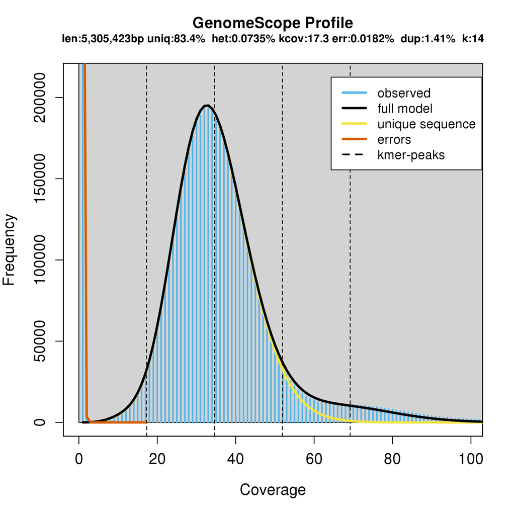

# 7. SSPACE Standard

Next, we will do a secondary scaffolding with the SPAdes assemblyusing a program called SSPACE. SSPACE is a script able to extend and scaffold pre-assembled contigs. The location of files:

```
SPAdes scaffold:
~/BIOL497R/notebooks/Ex5_assembly/SPAdes_out/scaffolds.fasta

SSPACE program:
~/BIOL497R/notebooks/Ex5_assembly/SSPACE/SSPACE_Standard_v3.0.pl
```

In addition, SSPACE requires a library file containing the paths to the paired end reads, average insert size, and type of data. This file is located at `library.txt`.

We will run `SSPACE_Standard_v3.0.pl` using a perl command with the parameters `-l` for the species library, `-s` for the fasta file containing assembled scaffolds, `-b` for the output prefix, and `-T` for the number of threads.

```python
%%bash

cat library.txt
```

```
SRR5714000 bowtie SRR5714000_sickle_1.fastq SRR5714000_sickle_2.fastq 300 0.25 FR
```

```python
%%bash

perl SSPACE/SSPACE_Standard_v3.0.pl -l library.txt -s SPAdes_out/scaffolds.fasta -b SSPACE_out -T 1
```

The output scaffold file is located at `~/BIOL497R/notebooks/Ex5_assembly/SSPACE_out/SSPACE_out.final.scaffolds.fasta`.

We then will run QUAST on this file to compare it with previous assemblies.

```python
%%bash

quast.py SSPACE_out/SSPACE_out.final.scaffolds.fasta -o SSPACE_out
```

What we find is that running SSPACE on the SPAdes scaffolds improves the assembly by reducing the number of contigs from 453 to 349, increases the longest contig to 548907 and increases the N50 to 233846.

```python
%%bash

cat SSPACE_out/report.txt
```

# 8. AlignGraph on close relation

AlignGraph is the final step in this assembly pipeline. From the documentation, AlignGraph is a software that extends and joins contigs or scaffolds by reassembling them with help provided by a reference genome of a closely related organism. By using a reference genome of a closely related organism, it can improve the assembly.

To run AlignGraph, we first need to convert the raw reads from fastq format to fasta format. There are many ways to do this, but one of the most efficient ways is to use a sed command to parse out the reads from the fastq file:

```python
%%bash

sed -n '1~4s/^@/>/p;2~4p' SRR5714000_sickle_1.fastq > SRR5714000_sickle_1.fasta
sed -n '1~4s/^@/>/p;2~4p' SRR5714000_sickle_2.fastq > SRR5714000_sickle_2.fasta
```

Then we will run AlignGraph using the `AlignGraph` command and the parameters `--read1` for the forward read in fasta format, `--read2` for the reverse read in fasta format, `--contig` for the path to the assembly we are rescaffolding, and `--genome` for the path to the reference genome we are using for rescaffolding. The genome we are using is named `Ecoli_genome.fa` and was obtained from NCBI - [Escherichia coli strain FDAARGOS_144](https://www.ncbi.nlm.nih.gov/nuccore/CP014111.1).

Additionally, we have to define the `--distanceLow` and `--distanceHigh` parameters. From the documentation, distanceLow is the maximum of [insert size – 1000, insert size] and distanceHigh [insert size + 1000]. The insert size of this dataset is 300, giving us a distanceLow of 300 and distanceHigh of 1300. Finally, we define the output file names using `--extendedContigs` and `--remainingContigs`. –remainingContigs will contain the final assembly. Lastly, we need to specify the **`--fastMap`** option to use the NUCMER alignment algorithm and if this option is missing the program will fail because the correct version of BLAT is not installed on the server.

```python
%%bash

AlignGraph --read1 SRR5714000_sickle_1.fasta --read2 SRR5714000_sickle_2.fasta \
           --contig SSPACE_out/SSPACE_out.final.scaffolds.fasta --genome Ecoli_genome.fa \
           --distanceLow 300 --distanceHigh 1300 --extendedContig Species_extendedContigs.fa \
           --remainingContig Species_remainingContigs.fa --fastMap \
```

The output file is located at `~/BIOL497R/notebooks/Ex5_assembly/Species_remainingContigs.fa`.

Then QUAST:

```python
%%bash

quast.py Species_remainingContigs.fa -o AlignGraph

cat AlignGraph/report.txt
```

Unfortunately, this dataset was not dramatically improved by AlignGraph with this specific genome, but the tutorial still illustrates the general idea that reference genome assemblies can be used to help scaffold de novo assemblies. It is important to note that improving a genome assembly becomes incrementally harder as you move closer to a complete or near complete genome assembly.